# **Analisis Fitur - Fitur yang Berpengaruh terhadap Penjualan Kopi Menggunakan Random Forest & XGBoost**

Dataset merupakan data simulasi penjualan produk kopi yang beroperasi di berbagai platform pada periode tahun 2025. Data terdiri dari 10.000 transaksi dengan 18 atribut. Tujuan dari analisis ini adalah mengetahui fitur (Atribut) mana saja yang berpengaruh terhadap penjualan kopi.

**IMPORT LIBRARIES**

```python
import pandas as pd
import numpy as np

# Visualization
import matplotlib.pyplot as plt
import seaborn as sns
%matplotlib inline

# Preprocessing & Pipeline
from sklearn.model_selection import train_test_split, GridSearchCV
from sklearn.preprocessing import OneHotEncoder
from sklearn.compose import ColumnTransformer
from sklearn.pipeline import Pipeline

# Models
from sklearn.ensemble import RandomForestRegressor
from xgboost import XGBRegressor

# Evaluation
from sklearn.metrics import mean_absolute_error, mean_squared_error, r2_score

# Interpretability
import shap

#Holidays
import holidays
```

**LOAD DATASET**

```python
# Load dataset
from google.colab import files
uploaded = files.upload()  # Upload Data

# Baca dataset
df = pd.read_excel('dataset_penjualan_kopi.xlsx')

# Menampilkan baris teratas
df.head()
```

Upload widget is only available when the cell has been executed in the current browser session. Please rerun this cell to enable.

```
Saving dataset_penjualan_kopi.xlsx to dataset_penjualan_kopi.xlsx
```

|  | Order_ID | Order_Date | Customer_ID | Platform | Payment_Method | City | Province | Age | Gender | Product_Category | Product_Name | Packaging_Size | Quantity | Unit_Price | Gross_Sales | Discount_Type | Discount_Percentage | Rating |
| --- | --- | --- | --- | --- | --- | --- | --- | --- | --- | --- | --- | --- | --- | --- | --- | --- | --- | --- |
| 0 | ORD00001 | 2025-08-17 | CUST1127 | Blibli | Paylater | Kab. Bondowoso | Jawa Timur | 43 | Female | Black Coffee | Black Coffee Plus Sugar | Small Pack | 4 | 2400 | 9600 | Payday Promo | 25 | 2 |
| 1 | ORD00002 | 2025-12-16 | CUST1460 | Lazada | COD | Kab. Bogor | Jawa Barat | 29 | Female | High Class | Arabica | Medium Pack | 1 | 95000 | 95000 | No Discount | 0 | 3 |
| 2 | ORD00003 | 2025-10-02 | CUST0861 | Lazada | COD | Kab. Batang | Jawa Tengah | 41 | Male | White Coffee | White Coffee Collagen | Medium Pack | 1 | 25000 | 25000 | Flash Sale | 39 | 4 |
| 3 | ORD00004 | 2025-10-06 | CUST1295 | Blibli | E-Wallet | Kab. Sleman | DI Yogyakarta | 24 | Female | Ready to Drink | Black Coffee Bottle | Multiple Pack | 1 | 47000 | 47000 | Wholesale | 13 | 5 |
| 4 | ORD00005 | 2025-09-08 | CUST1131 | Lazada | COD | Kab. Sragen | Jawa Tengah | 54 | Male | White Coffee | White Coffee Caramel | Large Pack | 2 | 47000 | 94000 | No Discount | 0 | 2 |

```python
#Ukuran Data
df.shape
```

```
(10000, 18)
```

**DATA UNDESTANDING**

```python
#Melihat Struktur Data
df.info()
```

```
<class 'pandas.core.frame.DataFrame'>
RangeIndex: 10000 entries, 0 to 9999
Data columns (total 18 columns):
 #   Column               Non-Null Count  Dtype
---  ------               --------------  -----
 0   Order_ID             10000 non-null  object
 1   Order_Date           10000 non-null  datetime64[ns]
 2   Customer_ID          10000 non-null  object
 3   Platform             10000 non-null  object
 4   Payment_Method       10000 non-null  object
 5   City                 10000 non-null  object
 6   Province             10000 non-null  object
 7   Age                  10000 non-null  int64
 8   Gender               10000 non-null  object
 9   Product_Category     10000 non-null  object
 10  Product_Name         10000 non-null  object
 11  Packaging_Size       10000 non-null  object
 12  Quantity             10000 non-null  int64
 13  Unit_Price           10000 non-null  int64
 14  Gross_Sales          10000 non-null  int64
 15  Discount_Type        10000 non-null  object
 16  Discount_Percentage  10000 non-null  int64
 17  Rating               10000 non-null  int64
dtypes: datetime64[ns](1), int64(6), object(11)
memory usage: 1.4+ MB
```

```python
#Mengubah Tipe Data Order Date ke Datetime
df['Order_Date'] = pd.to_datetime(df['Order_Date'])
#Cek Kembali Struktur Data
df.info()
```

```
<class 'pandas.core.frame.DataFrame'>
RangeIndex: 10000 entries, 0 to 9999
Data columns (total 18 columns):
 #   Column               Non-Null Count  Dtype
---  ------               --------------  -----
 0   Order_ID             10000 non-null  object
 1   Order_Date           10000 non-null  datetime64[ns]
 2   Customer_ID          10000 non-null  object
 3   Platform             10000 non-null  object
 4   Payment_Method       10000 non-null  object
 5   City                 10000 non-null  object
 6   Province             10000 non-null  object
 7   Age                  10000 non-null  int64
 8   Gender               10000 non-null  object
 9   Product_Category     10000 non-null  object
 10  Product_Name         10000 non-null  object
 11  Packaging_Size       10000 non-null  object
 12  Quantity             10000 non-null  int64
 13  Unit_Price           10000 non-null  int64
 14  Gross_Sales          10000 non-null  int64
 15  Discount_Type        10000 non-null  object
 16  Discount_Percentage  10000 non-null  int64
 17  Rating               10000 non-null  int64
dtypes: datetime64[ns](1), int64(6), object(11)
memory usage: 1.4+ MB
```

**DATA CLEANING**

```python
#Cek Missing Values
df.isnull().sum()
```

|  | 0 |
| --- | --- |
| Order_ID | 0 |
| Order_Date | 0 |
| Customer_ID | 0 |
| Platform | 0 |
| Payment_Method | 0 |
| City | 0 |
| Province | 0 |
| Age | 0 |
| Gender | 0 |
| Product_Category | 0 |
| Product_Name | 0 |
| Packaging_Size | 0 |
| Quantity | 0 |
| Unit_Price | 0 |
| Gross_Sales | 0 |
| Discount_Type | 0 |
| Discount_Percentage | 0 |
| Rating | 0 |

**dtype:** int64

```python
#Cek Duplikat
df.duplicated().sum()
```

```
np.int64(0)
```

**EXPLORATORY DATA ANALYSIS (EDA)**

```python
#Membuat kolom net sales terlebih dahulu
df['Net_Sales'] = df['Gross_Sales'] * (1 - df['Discount_Percentage']/100)
df['Net_Sales'].head()
```

|  | Net_Sales |
| --- | --- |
| 0 | 7200.0 |
| 1 | 95000.0 |
| 2 | 15250.0 |
| 3 | 40890.0 |
| 4 | 94000.0 |

**dtype:** float64

```python
#Deskriptif Penjualan
display(df['Net_Sales'].describe().round(2))
```

|  | Net_Sales |
| --- | --- |
| count | 10000.00 |
| mean | 122600.76 |
| std | 197934.55 |
| min | 1196.00 |
| 25% | 15000.00 |
| 50% | 60520.00 |
| 75% | 141900.00 |
| max | 1500000.00 |

**dtype:** float64

*Dataset terdiri dari 10.000 transaksi dengan rata-rata net sales sebesar Rp122.600.*

*Nilai net sales memiliki sebaran yang sangat lebar (std ≈ Rp197.934), menunjukkan adanya transaksi bernilai kecil hingga sangat besar.*

*Median (Rp60.520) lebih kecil dari rata-rata, menandakan distribusi condong ke kanan (right-skewed).*

*Kondisi ini umum pada data penjualan dan menjadi alasan yang tepat untuk menggunakan model tree-based (Random Forest & XGBoost) yang robust terhadap distribusi tidak normal dan outlier.*

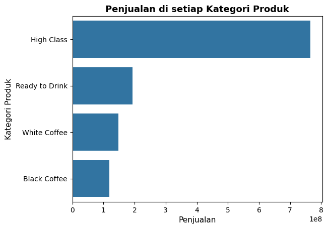

```python
#Penjualan di setiap Kategori Produk
#mengurutkan produk dari terbesar ke terkecil
Category_Sales = df.groupby('Product_Category')['Net_Sales'].sum().sort_values(ascending = False).reset_index()
sns.barplot(data = Category_Sales, x='Net_Sales', y='Product_Category')
plt.title('Penjualan di setiap Kategori Produk', fontsize=13, fontweight = 'bold')
plt.xlabel('Penjualan', fontsize = 11)
plt.ylabel('Kategori Produk', fontsize = 11)
```

*Meskipun dibandrol dengan harga premium, kategori 'High Class' mendominasi total net sales. Data ini membuktikan bahwa nilai jual (proposisi nilai) produk tersebut lebih berpengaruh terhadap keputusan pembelian pelanggan dibandingkan faktor harga.*

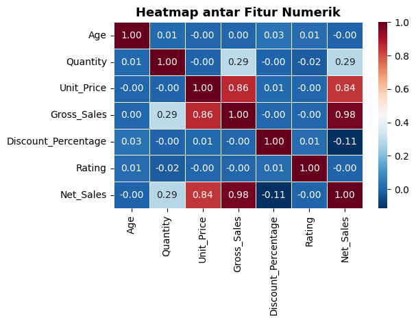

```python
# Korelasi antar Fitur Numerik
numeric_cols = df.select_dtypes(include=[np.number])
correlation_matrix = numeric_cols.corr()

sns.heatmap(correlation_matrix, annot = True, cmap = 'RdBu_r', fmt = '.2f', linewidths = 0.5)
plt.title('Heatmap antar Fitur Numerik', fontsize = 13, fontweight='bold')

plt.tight_layout()
plt.show()
```

*Heatmap antar fitur menunjukkan bahwa tidak semua fitur numerik memiliki hubungan linear yang kuat terhadap penjualan, sehingga diperlukan model non-linear untuk menangkap pola yang lebih kompleks.*

**FEATURE ENGINEERING**

```python
#Membuat kolom Is_Offday
# 1. Ekstraksi Fitur Dasar (Month, Day, Day of Week)
df['Month'] = df['Order_Date'].dt.month
df['Day'] = df['Order_Date'].dt.day
df['Day_of_Week'] = df['Order_Date'].dt.dayofweek

# 2. Mendapatkan Daftar Hari Libur Nasional Indonesia tahun 2025
id_holidays = holidays.Indonesia(years = 2025)

# 3. Membuat fungsi untuk menentukan Is_Offday
def check_offday(row):
    # Cek apakah hari Sabtu (5) atau Minggu (6)
    if row['Day_of_Week'] >= 5:
        return 1
    # Cek apakah tanggal tersebut ada di daftar libur nasional Indonesia
    if row['Order_Date'] in id_holidays:
        return 1
    return 0

# 4. Terapkan fungsi ke dataframe
df['Is_Offday'] = df.apply(check_offday, axis = 1)

# 5. Cek hasil (melihat data teratas yang merupakan hari libur)
print(f"Jumlah hari libur/weekend terdeteksi: {df['Is_Offday'].sum()} dari {len(df)} transaksi")
display(df[['Order_Date', 'Day_of_Week', 'Is_Offday']].head())
```

```
Jumlah hari libur/weekend terdeteksi: 3171 dari 10000 transaksi
```

|  | Order_Date | Day_of_Week | Is_Offday |
| --- | --- | --- | --- |
| 0 | 2025-08-17 | 6 | 1 |
| 1 | 2025-12-16 | 1 | 0 |
| 2 | 2025-10-02 | 3 | 0 |
| 3 | 2025-10-06 | 0 | 0 |
| 4 | 2025-09-08 | 0 | 0 |

*Order Date diolah menjadi fitur turunan seperti bulan, hari, & is offday (akhir pekan & hari libur nasional Indonesia) untuk menangkap pola perilaku belanja berdasarkan waktu. Hal ini dilakukan karena hari libur diduga dapat memengaruhi penjualan.*

```python
#Mengelompokkan Usia
# Menentukan batas-batas angka untuk setiap kategori
# Batas: 0-18, 18-25, 25-45, dan 45 ke atas
bins = [0, 18, 25, 45, 100]

# Menentukan label untuk masing-masing rentang tersebut
labels = ['Teens', 'Young Adult', 'Adult', 'Senior']

# Membuat kolom baru 'Age_Group'
df['Age_Group'] = pd.cut(df['Age'], bins = bins, labels = labels)

# Menampilkan beberapa baris
display(df[['Age', 'Age_Group']].head())
```

|  | Age | Age_Group |
| --- | --- | --- |
| 0 | 43 | Adult |
| 1 | 29 | Adult |
| 2 | 41 | Adult |
| 3 | 24 | Young Adult |
| 4 | 54 | Senior |

*Age dikelompokkan menjadi Age Group untuk mengurangi noise dari variasi usia individual serta perilaku belanja berdasarkan usia lebih baik diubah dalam bentuk segmen.*

**DEFINE X AND Y**

```python
#Variabel Target
y = df['Net_Sales']
#Features
X = df[['Is_Offday', 'Platform', 'Payment_Method', 'Province', 'Age_Group', 'Gender', 'Product_Category', 'Packaging_Size','Discount_Percentage']]
```

*Beberapa fitur tidak dimasukkan ke dalam variabel X dengan pertimbangan sebagai berikut:*

- City; tidak digunakan untuk menghindari granularitas yang terlalu tinggi yang berpotensi menambah kompleksitas model.
- Product Name; informasinya telah direpresentasikan secara konseptual oleh Product Category, sehingga berpotensi menimbulkan redundansi fitur.
- Quantity, Unit Price, & Gross Sales; merupakan komponen langsung pembentuk Net Sales, sehingga berisiko menyebabkan data leakage.
- Discount Type; informasinya telah direpresentasikan secara kuantitatif melalui Discount Percentage, yang lebih informatif untuk pemodelan.
- Rating; umumnya merupakan hasil setelah transaksi terjadi, sehingga kurang tepat digunakan sebagai variabel penjelas dalam analisis faktor yang memengaruhi penjualan.

**TRAIN-TEST SPLIT**

```python
X_train, X_test, y_train, y_test = train_test_split(X, y, test_size=0.2, random_state=42)
```

**MODEL BUILDING**

```python
#Preprocessing
# Identifikasi fitur
categorical_features = X_train.select_dtypes(include=['object', 'category']).columns
numeric_features = X_train.select_dtypes(exclude=['object', 'category']).columns

# Preprocessor
preprocessor = ColumnTransformer(
    transformers=[
        ('cat', OneHotEncoder(handle_unknown='ignore', sparse_output=False), categorical_features),
        ('num', 'passthrough', numeric_features)
    ]
)
```

**Model 1 - Random Forest Regressor**

```python
rf = Pipeline(steps=[
    ('preprocessor', preprocessor),
    ('model', RandomForestRegressor(
        n_estimators=200,
        random_state=42,
        n_jobs=-1
    ))
])
# Training
rf.fit(X_train, y_train)
# Prediksi
y_pred_rf = rf.predict(X_test)
```

**Model 2 - XGB Regressor**

```python
xgb = Pipeline(steps=[
    ('preprocessor', preprocessor),
    ('model', XGBRegressor(
        n_estimators=300,
        learning_rate=0.1,
        max_depth=6,
        subsample=0.8,
        colsample_bytree=0.8,
        objective='reg:squarederror',
        random_state=42
    ))
])
# Training
xgb.fit(X_train, y_train)
# Prediksi
y_pred_xgb = xgb.predict(X_test)
```

**Pemilihan Model**

```python
def evaluate_model(y_true, y_pred, model_name, dataset_type):
    print(f"=== {model_name} - {dataset_type} Set ===")
    print("MAE :", mean_absolute_error(y_true, y_pred))
    print("RMSE:", np.sqrt(mean_squared_error(y_true, y_pred)))
    print("R²  :", r2_score(y_true, y_pred))
    print()

# Prediksi pada data training untuk evaluasi
y_pred_rf_train = rf.predict(X_train)
y_pred_xgb_train = xgb.predict(X_train)

# Evaluasi Random Forest pada data training
evaluate_model(y_train, y_pred_rf_train, "Random Forest", "Train")
# Evaluasi Random Forest pada data testing
evaluate_model(y_test, y_pred_rf, "Random Forest", "Test")

# Evaluasi XGBoost pada data training
evaluate_model(y_train, y_pred_xgb_train, "XGBoost", "Train")
# Evaluasi XGBoost pada data testing
evaluate_model(y_test, y_pred_xgb, "XGBoost", "Test")
```

```
=== Random Forest - Train Set ===
MAE : 21534.63859607066
RMSE: 45217.833374011134
R²  : 0.9470344348351731

=== Random Forest - Test Set ===
MAE : 58963.91004882792
RMSE: 120626.68809282208
R²  : 0.648621094963103

=== XGBoost - Train Set ===
MAE : 32997.73929497338
RMSE: 61648.03272309773
R²  : 0.9015507171642511

=== XGBoost - Test Set ===
MAE : 60536.18745354462
RMSE: 125576.16767305328
R²  : 0.6191943991460787
```

*Kedua model mengindikasikan potensi overfitting melalui performa training yang sangat tinggi namun rendah pada testing.*

*Oleh karena itu, model akan dipilih berdasarkan selisih antarperforma di training maupun testing terkecil.*

*Model terpilih akan dilakukan hyperparameter tuning untuk meningkatkan kebaikan model serta menurunkan risiko overfitting.*

**Hyperparameter Tuning**

```python
# Menentukan parameter untuk tuning model XGBoost
param_grid = {
    'model__n_estimators': [100, 200, 300],
    'model__learning_rate': [0.01, 0.05, 0.1],
    'model__max_depth': [3, 5, 7],
    'model__subsample': [0.7, 0.8, 1.0],
    'model__colsample_bytree': [0.7, 0.8, 1.0]
}

# Tuning XGB
xgb_tuning = Pipeline(steps=[
    ('preprocessor', preprocessor),
    ('model', XGBRegressor(objective='reg:squarederror', random_state=42, enable_categorical=True))
])

# Inisialisasi GridSearch
grid_search = GridSearchCV(
    estimator=xgb_tuning,
    param_grid=param_grid,
    cv=3,
    scoring='r2',
    n_jobs=-1,
    verbose=2
)

# Proses Tuning
grid_search.fit(X_train, y_train)

# Menampilkan Parameter Terbaik
print(f"Best Parameters: {grid_search.best_params_}")
best_xgb_model = grid_search.best_estimator_

# Prediksi dengan model terbaik
y_pred_best_xgb = best_xgb_model.predict(X_test)
```

```
Fitting 3 folds for each of 243 candidates, totalling 729 fits
Best Parameters: {'model__colsample_bytree': 0.8, 'model__learning_rate': 0.05, 'model__max_depth': 3, 'model__n_estimators': 100, 'model__subsample': 0.7}
```

**Final Model Evaluation**

```python
# Prediksi dengan model terbaik pada data training
y_pred_best_xgb_train = best_xgb_model.predict(X_train)

# Evaluasi model terbaik pada data training
print("Best XGBoost Model Evaluation - Train Set:")
print(f"  MAE : {mean_absolute_error(y_train, y_pred_best_xgb_train):.4f}")
print(f"  RMSE: {np.sqrt(mean_squared_error(y_train, y_pred_best_xgb_train)):.4f}")
print(f"  R²  : {r2_score(y_train, y_pred_best_xgb_train):.4f}")

# Evaluasi model terbaik pada data testing
print("\nBest XGBoost Model Evaluation - Test Set:")
print(f"  MAE : {mean_absolute_error(y_test, y_pred_best_xgb):.4f}")
print(f"  RMSE: {np.sqrt(mean_squared_error(y_test, y_pred_best_xgb)):.4f}")
print(f"  R²  : {r2_score(y_test, y_pred_best_xgb):.4f}")
```

```
Best XGBoost Model Evaluation - Train Set:
  MAE : 51540.5496
  RMSE: 105140.4752
  R²  : 0.7136

Best XGBoost Model Evaluation - Test Set:
  MAE : 55003.5643
  RMSE: 110155.8970
  R²  : 0.7070
```

*Hasil ini menunjukkan bahwa model telah memiliki kemampuan generalisasi yang lebih baik & tidak lagi menunjukkan indikasi overfitting. Model XGBoost hasil tuning ini dipilih sebagai final model.*

**FEATURE IMPORTANCE**

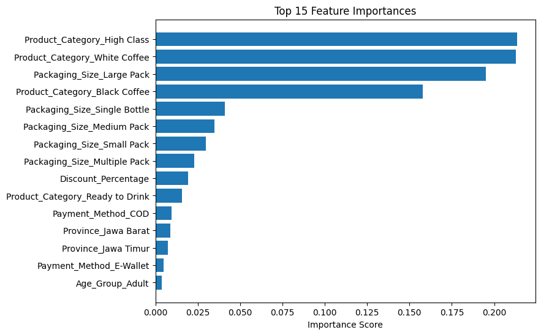

```python
# Mengambil preprocessor dari pipeline
preprocessor = best_xgb_model.named_steps['preprocessor']

# Mengambil feature hasil encoding
feature_names_cat = preprocessor.named_transformers_['cat'] \
    .get_feature_names_out(categorical_features)

feature_names_num = numeric_features

# Gabungkan
feature_names = list(feature_names_cat) + list(feature_names_num)

# Mengambil model XGBoost
xgb_model = best_xgb_model.named_steps['model']

# Membuat dataframe feature importance
feature_importance = pd.DataFrame({
    'feature': feature_names,
    'importance': xgb_model.feature_importances_
}).sort_values(by='importance', ascending=False)

#TOP 15 FITUR PENTING
plt.figure(figsize=(8,6))
plt.barh(
    feature_importance.head(15)['feature'],
    feature_importance.head(15)['importance']
)
plt.gca().invert_yaxis()
plt.title('Top 15 Feature Importances')
plt.xlabel('Importance Score')
plt.show()
```

*Analisis kontribusi fitur menggunakan XGBoost menunjukkan beberapa temuan sebagai berikut.*

1. **Dominasi Kategori Produk sebagai Driver Pendapatan Utama** Tiga dari empat fitur paling berpengaruh adalah kategori produk. Hal ini menegaskan bahwa **komoditas yang ditawarkan** memiliki dampak yang jauh lebih signifikan terhadap nilai transaksi dibandingkan profil demografis maupun lokasi geografis pelanggan.
2. **Pengaruh Ukuran Kemasan terhadap Nilai Transaksi** Fitur Packaging_Size_Large_Pack menempati urutan ketiga, menunjukkan bahwa preferensi pelanggan terhadap **ukuran kemasan besar** merupakan indikator kuat bagi transaksi bernilai tinggi (*high-value orders*).
3. **Efektivitas Diskon yang Moderat** Discount_Percentage berada di posisi menengah, menandakan bahwa strategi promosi harga memang memengaruhi penjualan, namun tidak sedominan pengaruh jenis produk & ukuran kemasan dalam menentukan penjualan.
4. Variabel **Demografis & Geografis** seperti lokasi provinsi, metode pembayaran, & kelompok usia memiliki **pengaruh yang relatif kecil**. Hal ini mengindikasikan bahwa perilaku belanja kopi cenderung **seragam** di berbagai segmen pasar & wilayah.

**SHAP VALUES**

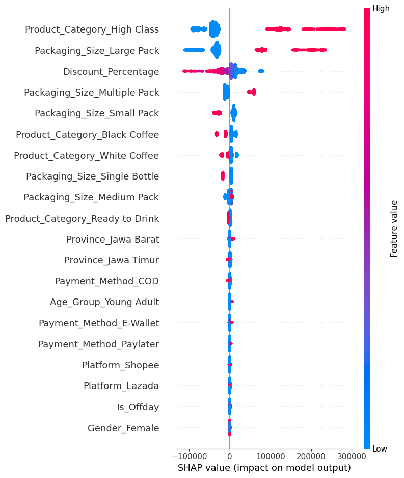

```python
# Transform X_test menggunakan preprocessor
X_test_transformed = preprocessor.transform(X_test)

#SHAP Explainer Model XGBoost
explainer = shap.TreeExplainer(xgb_model)
shap_values = explainer.shap_values(X_test_transformed)

#SHAP Summary Plot
shap.summary_plot(
    shap_values,
    X_test_transformed,
    feature_names=feature_names
)
```

*Hasil analisis menggunakan SHAP Values memperkuat temuan dengan memberikan informasi mengenai arah & besar pengaruh masing-masing fitur terhadap penjualan. Penjelasannya adalah sebagai berikut.*

1. **Produk Premium sebagai Penggerak Utama** Product_Category_High Class: Ini adalah fitur paling dominan. Titik-titik merah (nilai fitur tinggi/YA) berada jauh di sisi kanan (positif). Maka: Ketika sebuah transaksi melibatkan kategori High Class, model secara drastis **menaikkan** prediksi net sales hingga lebih dari Rp200.000.
2. **Ukuran Kemasan** Packaging_Size_Large Pack: Fitur ini menempati urutan kedua dengan pola yang serupa. Titik merah berada di sisi kanan. Maka: Pelanggan yang membeli kemasan besar berkontribusi signifikan pada **peningkatan** nilai transaksi. Sebaliknya, titik biru (bukan large pack) berkontribusi menurunkan nilai prediksi penjualan.
3. **Fenomena pada Diskon** Titik merah (diskon tinggi) justru berkumpul di sisi Kiri (negatif). Maka: pemberian diskon yang terlalu besar justru **menurunkan** penjualan per transaksi.
4. **Kontribusi Variabel Lain** Is_Offday & fitur-fitur demografis berada dibagian bawah dengan sebaran titik yang rapat di garis nol. Maka: Faktor hari libur atau demografis memberikan **dampak kecil** terhadap nilai penjualan secara individu.

**CONCLUSION**

*Model XGBoost berhasil mengidentifikasi bahwa pendorong utama pertumbuhan penjualan kopi tahun 2025 bukanlah pada promosi harga (diskon), melainkan pada kekuatan segmentasi produk premium dan ukuran kemasan. Dengan memprioritaskan kategori High Class & mendorong pembelian Large Pack, perusahaan dapat meningkatkan efisiensi pendapatan tanpa harus mengorbankan margin keuntungan melalui diskon yang berlebihan.*